# 1-RNN

RNN (Recurrent Neural Network)

RNN is a type of neural network designed for processing sequences of data by maintaining a hidden state that captures information from previous inputs.

1. How the hidden state loops (for both single-layer and multi-layer RNNs).
2. What are the two outputs of an RNN layer in pytorch, and what are the shapes?
3. How the hidden state is differentiated.

For **how the hidden state loops**, refer to the diagrams and code in *Single Layer RNN* and *Multi Layer RNN*.

For **how the hidden state is differentiated**, refer to the derivation of gradients and the implementation from scratch.

## --- Single Layer RNN Architecture

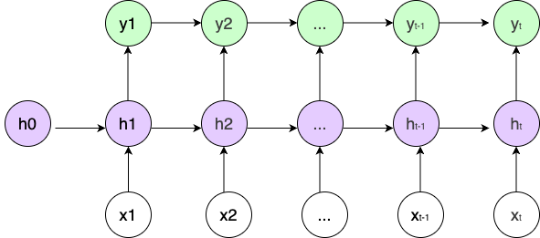

The mathematical formula is as follows: at each time step $t$, the hidden state $h_t$ is computed based on the current input $x_t$ and the previous hidden state $h_{t-1}$. This is typically formulated as $$h_t = \psi(W_{xh} x_t + W_{hh} h_{t-1} + b_h)$$ where $W_{xh}$ is the weight matrix for the input, $W_{hh}$ is the weight matrix for the hidden state (notice that if $W_{hh}$ is zero, then RNN degrades to MLP), $b_h$ is the bias term, and $\psi$ is an activation function such as tanh or ReLU.

The output $y_t$ at each time step can be given by $$y_t = \phi(W_{hy} h_t + b_y)$$ where $W_{hy}$ is the weight matrix from the hidden state to the output, $b_y$ is the bias term for the output and $\phi$ is an activation function.

#### Single Layer RNN Implementation

I will implement the same simple RNN architecture (with input_size=2, hidden_size=2, output_size=1, sequence_length=3) using three different approaches. First, I build it completely from scratch with manual forward and backward propagation. Then, I show how to implement the same model using PyTorch, and finally with TensorFlow/Keras.

```python
import numpy as np

# Define the RNN parameters
input_size = 2
hidden_size = 2
output_size = 1
sequence_length = 3
learning_rate = 0.1
```

From Scratch

```python
# Initialize RNN weights and biases
Wxh = np.random.randn(hidden_size, input_size)  # Weight matrix for input to hidden
Whh = np.random.randn(hidden_size, hidden_size) # Weight matrix for hidden to hidden
Why = np.random.randn(output_size, hidden_size) # Weight matrix for hidden to output
bh = np.zeros((hidden_size, 1))                 # Bias for hidden
by = np.zeros((output_size, 1))                 # Bias for output

# Define the input sequence and target output
input_sequence = np.array([[0, 1], [1, 0], [1, 1]])  # Example input sequence
target_output = np.array([[1], [1], [0]])            # Example target output

# Forward pass
hs = np.zeros((sequence_length, hidden_size, 1))  # Hidden states
ys = np.zeros((sequence_length, output_size, 1))  # Outputs

for t in range(sequence_length):
    # Input at time step t
    xt = input_sequence[t].reshape(-1, 1)

    # Compute hidden state at time step t
    hs[t] = np.tanh(np.dot(Wxh, xt) + np.dot(Whh, hs[t-1]) + bh)

    # Compute output at time step t
    ys[t] = np.dot(Why, hs[t]) + by

# Compute loss
loss = np.mean((ys - target_output)**2)

# Backward pass (backpropagation through time)
dWxh, dWhh, dWhy = np.zeros_like(Wxh), np.zeros_like(Whh), np.zeros_like(Why)
dbh, dby = np.zeros_like(bh), np.zeros_like(by)
dh_next = np.zeros_like(hs[0])

for t in reversed(range(sequence_length)):
    dy = ys[t] - target_output[t]
    dWhy += np.dot(dy, hs[t].T)
    dby += dy
    dh = np.dot(Why.T, dy) + dh_next
    dhraw = (1 - hs[t] ** 2) * dh
    dbh += dhraw
    dWxh += np.dot(dhraw, input_sequence[t].reshape(1, -1))
    dWhh += np.dot(dhraw, hs[t-1].T)
    dh_next = np.dot(Whh.T, dhraw)

# Update weights and biases
Wxh -= learning_rate * dWxh
Whh -= learning_rate * dWhh
Why -= learning_rate * dWhy
bh -= learning_rate * dbh
by -= learning_rate * dby

# Print loss
print("Loss:", loss)
```

```
Loss: 1.8370785003716503
```

Pytorch Normal Version

```python
import torch
import torch.nn as nn

# ----- Dummy data -----
x = torch.tensor([[0, 1], [1, 0], [1, 1]], dtype=torch.float32).unsqueeze(1)  # (T, batch, input_size)
y = torch.tensor([[1], [1], [0]], dtype=torch.float32).unsqueeze(1)            # (T, batch, output_size)

# ----- Architecture -----
class SimpleRNN(nn.Module):
    def __init__(self, input_size, hidden_size, output_size): # hidden_size is the dimension of the hidden state
        super().__init__()
        self.rnn = nn.RNN(input_size, hidden_size, batch_first=False, nonlinearity="tanh")
        self.fc = nn.Linear(hidden_size, output_size)

    def forward(self, x):
        # x: (T, batch, input_size)
        h0 = torch.zeros(1, x.size(1), hidden_size)  # hidden state
        out, hn = self.rnn(x, h0)                    # out: (T, batch, hidden_size). contains h1, h2, ..., hT at the top hiddenlayer
        y_pred = self.fc(out)                        # (T, batch, output_size)
        return y_pred

model = SimpleRNN(input_size, hidden_size, output_size)

# ----- Loss & Optimizer -----
criterion = nn.MSELoss()
optimizer = torch.optim.SGD(model.parameters(), lr=learning_rate)

# ----- Forward + Backward -----
y_pred = model(x)
loss = criterion(y_pred, y)
optimizer.zero_grad()
loss.backward()
optimizer.step()

print("Loss:", loss.item())
```

```
Loss: 1.767337441444397
```

Tensorflow Normal Version

```python
import tensorflow as tf
from tensorflow.keras import layers, models

# ----- Dummy data -----
x = tf.constant([[[0, 1], [1, 0], [1, 1]]], dtype=tf.float32)
y = tf.constant([[[1], [1], [0]]], dtype=tf.float32)

# ----- Architecture -----
inputs = layers.Input(shape=(sequence_length, input_size))
rnn_out = layers.SimpleRNN(hidden_size,
                           activation="tanh",
                           return_sequences=True)(inputs)  # shape: (batch_size, sequence_length, hidden_size)
outputs = layers.TimeDistributed(layers.Dense(output_size))(rnn_out)  # shape: (batch_size, sequence_length, output_size)

model = models.Model(inputs, outputs)

# ----- Compile -----
model.compile(optimizer=tf.keras.optimizers.SGD(learning_rate=learning_rate),
              loss="mse")

# ----- Train one step -----
loss = model.train_on_batch(x, y)
print("Loss:", loss)
```

```
Loss: 0.57874405
```

## --- Multi Layer RNN Architecture

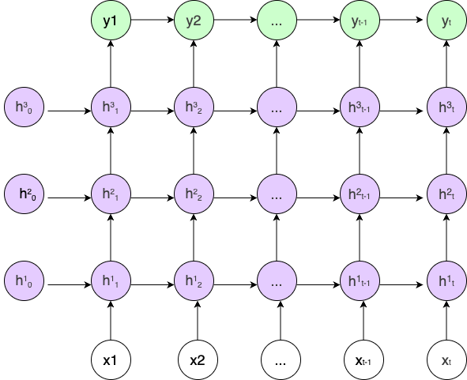

In a **multi-layer RNN**, also known as a stacked RNN, each time step $t$ involves multiple layers of hidden states. Let $h_t^{(l)}$ denote the hidden state at time $t$ and layer $l$. The hidden state of the **first layer** is computed similarly to a standard RNN:

$$h_t^{(1)} = \sigma(W_{x}^{(1)} x_t + W_{h}^{(1)} h_{t-1}^{(1)} + b^{(1)}),$$

where $W_{x}^{(1)}$ is the input-to-hidden weight matrix for the first layer, $W_{h}^{(1)}$ is the recurrent weight matrix within the first layer, and $b^{(1)}$ is the corresponding bias.

For **higher layers** ($l = 2, \dots, L$), each hidden state is computed based on the hidden state from the **previous layer at the same time step**, and its own **previous time step's** hidden state:

$$h_t^{(l)} = \sigma(W_{x}^{(l)} h_t^{(l-1)} + W_{h}^{(l)} h_{t-1}^{(l)} + b^{(l)}),$$

where $W_{x}^{(l)}$ now maps from the hidden state of layer $l-1$ to layer $l$, and $W_{h}^{(l)}$ captures the recurrent connection in layer $l$.

The **output** $y_t$ at each time step is typically computed from the hidden state of the **topmost layer** (layer $L$):

$$y_t = \phi(W_{hy} h_t^{(L)} + b_y),$$

where $W_{hy}$ and $b_y$ are the output weight matrix and bias, respectively.

> **RNN and Dynamic Programming**

> The information flow in **Multilayer RNNs** is completely consistent with the recurrence direction in **dynamic programming (DP) matrices**.

> In a **Multilayer RNN**, information propagates along both the **time dimension** (from $t-1 \to t$) and the **layer dimension** (from layer $l-1 \to l$). Thus, the computation of a hidden state $h_{t}^{(l)}$ depends on:
> - the previous time step in the same layer, $h_{t-1}^{(l)}$, and
> - the current time step in the previous layer, $h_{t}^{(l-1)}$.

> This matches exactly the dependency pattern of a **two-dimensional DP matrix**: $$ dp[t][l] \;=\; f\big(dp[t-1][l],\; dp[t][l-1],\; \text{input}\big) $$ In other words, the forward propagation of a multilayer RNN is essentially performing **recursive updates** over a two-dimensional grid of "time × layers," with the same direction as DP.

#### Multi Layer RNN Implementation

I will implement a multi-layer RNN architecture with input_size=2, hidden_size=2, output_size=1, sequence_length=3, and num_layers=2. I will show three approaches: first building it from scratch with manual forward and backward propagation, then implementing it using PyTorch, and finally using TensorFlow/Keras.

```python
import numpy as np

# Define parameters
input_size = 2
hidden_size = 2
output_size = 1
sequence_length = 3
num_layers = 2
learning_rate = 0.1
device = "cpu"
```

From Scratch

```python
# Initialize weights and biases for each layer
# Dimensions: (hidden_size, input_size) for the first layer, (hidden_size, hidden_size) for subsequent layers
Wxh = [np.random.randn(hidden_size, input_size if l == 0 else hidden_size) for l in range(num_layers)]
# Dimensions: (hidden_size, hidden_size) for all layers
Whh = [np.random.randn(hidden_size, hidden_size) for _ in range(num_layers)]
# Dimensions: (hidden_size, 1) for all layers
bh = [np.zeros((hidden_size, 1)) for _ in range(num_layers)]

# Output layer weights (from top RNN layer)
Why = np.random.randn(output_size, hidden_size)
by = np.zeros((output_size, 1))

# Input and target
input_sequence = np.array([[0, 1], [1, 0], [1, 1]])
target_output = np.array([[1], [1], [0]])

# Forward pass
hs = np.zeros((sequence_length, num_layers, hidden_size, 1))  # hidden states per layer
ys = np.zeros((sequence_length, output_size, 1))              # output per time step

for t in range(sequence_length):
    x = input_sequence[t].reshape(-1, 1)
    for l in range(num_layers):
        prev_h = hs[t-1, l] if t > 0 else np.zeros((hidden_size, 1))
        input_to_layer = x if l == 0 else hs[t, l-1]
        hs[t, l] = np.tanh(np.dot(Wxh[l], input_to_layer) + np.dot(Whh[l], prev_h) + bh[l])
    ys[t] = np.dot(Why, hs[t, -1]) + by  # Output from last RNN layer

# Loss
loss = np.mean((ys - target_output)**2)

# Backward pass (BPTT for 2-layer RNN)
dWxh = [np.zeros_like(W) for W in Wxh]
dWhh = [np.zeros_like(W) for W in Whh]
dbh = [np.zeros_like(b) for b in bh]
dWhy = np.zeros_like(Why)
dby = np.zeros_like(by)
dh_next = [np.zeros((hidden_size, 1)) for _ in range(num_layers)]

for t in reversed(range(sequence_length)):
    dy = ys[t] - target_output[t]
    dWhy += np.dot(dy, hs[t, -1].T)
    dby += dy

    dh = [np.zeros((hidden_size, 1)) for _ in range(num_layers)]
    dh[-1] = np.dot(Why.T, dy) + dh_next[-1]

    for l in reversed(range(num_layers)):
        h = hs[t, l]
        dhraw = (1 - h ** 2) * dh[l]
        dbh[l] += dhraw
        input_to_layer = input_sequence[t].reshape(-1, 1) if l == 0 else hs[t, l-1]
        prev_h = hs[t-1, l] if t > 0 else np.zeros_like(h)

        dWxh[l] += np.dot(dhraw, input_to_layer.T)
        dWhh[l] += np.dot(dhraw, prev_h.T)

        if l > 0:
            dh[l-1] = np.dot(Wxh[l].T, dhraw) + dh_next[l-1]
        dh_next[l] = np.dot(Whh[l].T, dhraw)

# Update weights and biases
for l in range(num_layers):
    Wxh[l] -= learning_rate * dWxh[l]
    Whh[l] -= learning_rate * dWhh[l]
    bh[l] -= learning_rate * dbh[l]

Why -= learning_rate * dWhy
by -= learning_rate * dby

print("Loss:", loss)
```

```
Loss: 4.053545353348784
```

Pytorch Normal Version

```python
import torch
import torch.nn as nn

# ----- Data -----
# x: (T, batch, input_size), y: (T, batch, output_size)
x = torch.tensor([[0., 1.],
                  [1., 0.],
                  [1., 1.]], dtype=torch.float32).unsqueeze(1)   # (3, 1, 2)
y = torch.tensor([[1.],
                  [1.],
                  [0.]], dtype=torch.float32).unsqueeze(1)       # (3, 1, 1)

# ----- Model -----
class StackedRNN(nn.Module):
    def __init__(self, input_size, hidden_size, output_size, num_layers):
        super().__init__()
        self.rnn = nn.RNN(
            input_size=input_size,
            hidden_size=hidden_size,
            num_layers=num_layers,
            nonlinearity="tanh",
            batch_first=False,     # (T, B, H)
        )
        self.fc = nn.Linear(hidden_size, output_size)  # Top layer readout

    def forward(self, x):
        # x: (T, B, input_size)
        h0 = torch.zeros(num_layers, x.size(1), hidden_size, device=x.device)
        out_all, _ = self.rnn(x, h0)                  # (T, B, H) contains h1, h2, ..., hT at the top hiddenlayer
        y_pred = self.fc(out_all)                     # (T, B, output_size)
        return y_pred

model = StackedRNN(input_size, hidden_size, output_size, num_layers).to(device)

criterion = nn.MSELoss()
optimizer = torch.optim.SGD(model.parameters(), lr=learning_rate)

# ----- One training step -----
model.train()
y_pred = model(x)
loss = criterion(y_pred, y)
optimizer.zero_grad()
loss.backward()
optimizer.step()

print("PyTorch Loss:", loss.item())
```

```
PyTorch Loss: 0.44763097167015076
```

Tensorflow Normal Version

```python
import tensorflow as tf
from tensorflow.keras import layers, models

# ----- Data -----
# Shape: (batch, T, input_size) and (batch, T, output_size)
x = tf.constant([[[0., 1.],
                  [1., 0.],
                  [1., 1.]]], dtype=tf.float32)   # (1, 3, 2)
y = tf.constant([[[1.],
                  [1.],
                  [0.]]], dtype=tf.float32)       # (1, 3, 1)

# ----- Model -----
inputs = layers.Input(shape=(sequence_length, input_size))
rnn = layers.SimpleRNN(hidden_size, activation="tanh", return_sequences=True)(inputs)  # (batch, T, hidden_size)
for _ in range(num_layers - 1):
    rnn = layers.SimpleRNN(hidden_size, activation="tanh", return_sequences=True)(rnn)  # (batch, T, hidden_size)
outputs = layers.TimeDistributed(layers.Dense(output_size))(rnn)  # (batch, T, output_size)

model = models.Model(inputs, outputs)
model.compile(optimizer=tf.keras.optimizers.SGD(learning_rate=learning_rate),
              loss="mse")

# ----- One training step -----
loss = model.train_on_batch(x, y)
print("TensorFlow Loss:", float(loss))
```

```
TensorFlow Loss: 1.0210273265838623
```

## --- RNN Backpropagation

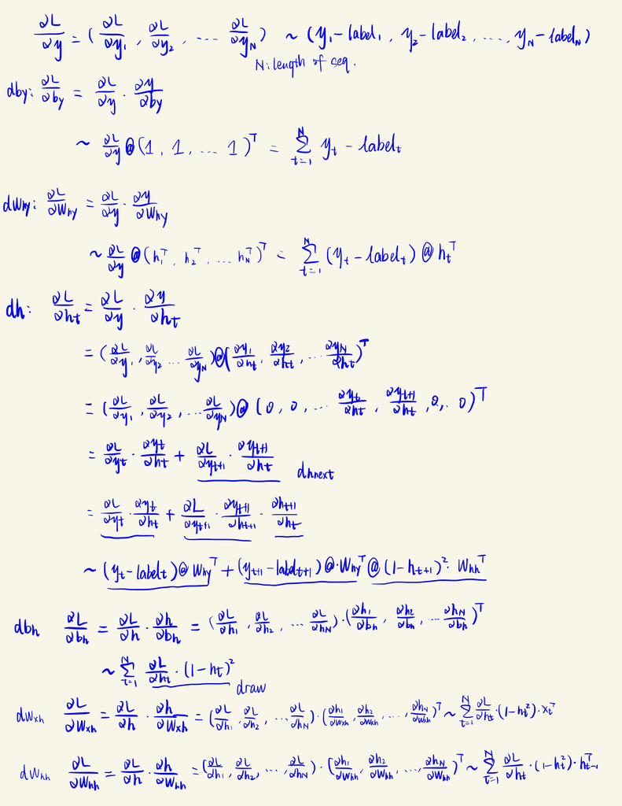